# Malaria Deaths and Malnutrition in ASEAN Countries (2020) - ggplot2 Version

## Introduction

This report analyzes the relationship between malaria deaths in children aged 1-59 months and malnutrition (weight for age) among children under 5 in ASEAN countries for the year 2020. ASEAN (Association of Southeast Asian Nations) includes 10 member countries that face various public health challenges.

```r
# Load the datasets
malaria_data <- read.csv("malaria_deaths_in_children_1_59_months_total_deaths.csv")
malnutrition_data <- read.csv("malnutrition_weight_for_age_percent_of_children_under_5.csv")

# Display structure of datasets
cat("Malaria Deaths Dataset Structure:\n")
```

```
## Malaria Deaths Dataset Structure:
```

```r
print(head(malaria_data, 3))
```

```
##       country X1990 X1991 X1992 X1993 X1994 X1995 X1996 X1997 X1998 X1999 X2000
## 1 Afghanistan  20.7  45.7  48.1    23  40.4  41.8  39.8  60.2   150   128  70.2
## 2      Angola  4680  4950  5220  5580  5940  6290  6650  7090  7670  8260  8560
## 3     Albania     0     0     0     0     0     0     0     0     0     0     0
##   X2001 X2002 X2003 X2004 X2005 X2006 X2007 X2008 X2009 X2010 X2011 X2012 X2013
## 1  58.1   741   527   146  93.8  90.3  80.9  44.6    39  63.1  65.8    13  23.4
## 2  9230  9680 10.7k 11.7k 12.1k 11.5k 10.4k  8820  7200  6170  5380  5110  5000
## 3     0     0     0     0     0     0     0     0     0     0     0     0     0
##   X2014 X2015 X2016 X2017 X2018 X2019 X2020 X2021
## 1    41  55.6  98.9   116  69.8  13.7  12.3  17.5
## 2  5130  5730  6010  6490  6850  6990  7750 10.1k
## 3     0     0     0     0     0     0     0     0
```

```r
cat("\nMalnutrition Dataset Structure:\n")
```

```
##
## Malnutrition Dataset Structure:
```

```r
print(head(malnutrition_data, 3))
```

```
##       country X1983 X1984 X1985 X1986 X1987 X1988 X1989 X1990 X1991 X1992 X1993
## 1 Afghanistan    NA    NA    NA    NA    NA    NA    NA    NA    NA    NA    NA
## 2      Angola    NA    NA    NA    NA    NA    NA    NA    NA    NA    NA    NA
## 3     Albania    NA    NA    NA    NA    NA    NA    NA    NA    NA    NA    NA
##   X1994 X1995 X1996 X1997 X1998 X1999 X2000 X2001 X2002 X2003 X2004 X2005 X2006
## 1    NA    NA    NA  44.9    NA    NA    NA    NA    NA    NA  31.7    NA    NA
## 2    NA    NA  36.2    NA    NA    NA    NA    NA    NA    NA    NA    NA    NA
## 3    NA    NA    NA    NA    NA    NA    NA    NA    NA    NA    NA   6.6    NA
##   X2007 X2008 X2009 X2010 X2011 X2012 X2013 X2014 X2015 X2016 X2017 X2018 X2019
## 1    NA    NA    NA    NA    NA    NA  24.6    NA    NA    NA    NA  19.1    NA
## 2  15.1    NA    NA    NA    NA    NA    NA    NA    19    NA    NA    NA    NA
## 3    NA    NA   6.3    NA    NA    NA    NA    NA    NA    NA   1.5    NA    NA
##   X2020 X2021 X2022 X2023 X2024
## 1    NA    NA  18.4    NA    NA
## 2    NA    NA    NA    NA    NA
## 3    NA    NA    NA    NA    NA
```

```r
# Define ASEAN countries
asean_countries <- c("Brunei", "Cambodia", "Indonesia", "Laos", "Malaysia",
                     "Myanmar", "Philippines", "Singapore", "Thailand", "Vietnam")

# Alternative names that might appear in the data
asean_alt_names <- c("Brunei Darussalam", "Lao PDR", "Lao People's Democratic Republic",
                     "Viet Nam", "Brunei", "Burma")
```

```r
# Extract 2020 data for ASEAN countries from malaria dataset
malaria_2020 <- malaria_data %>%
  select(country, `X2020`) %>%
  rename(malaria_deaths_2020 = `X2020`) %>%
  filter(country %in% c(asean_countries, asean_alt_names) |
         str_detect(country, paste(asean_countries, collapse = "|"))) %>%
  mutate(malaria_deaths_2020 = as.numeric(malaria_deaths_2020))

# For malnutrition, use the most recent available data (prioritizing recent years)
malnutrition_recent <- malnutrition_data %>%
  filter(country %in% c(asean_countries, asean_alt_names) |
         str_detect(country, paste(asean_countries, collapse = "|"))) %>%
  # Convert to long format to find most recent non-NA value
  pivot_longer(cols = -country, names_to = "year", values_to = "malnutrition_pct") %>%
  mutate(year = as.numeric(str_remove(year, "X")),
         malnutrition_pct = as.numeric(malnutrition_pct)) %>%
  filter(!is.na(malnutrition_pct), year >= 2015) %>%  # Focus on recent years
  group_by(country) %>%
  slice_max(year, n = 1) %>%  # Get most recent value per country
  ungroup() %>%
  select(country, malnutrition_pct, year) %>%
  rename(malnutrition_pct_recent = malnutrition_pct, malnutrition_year = year)

# Display the subsetted data
cat("ASEAN Countries - Malaria Deaths 2020:\n")
```

```
## ASEAN Countries - Malaria Deaths 2020:
```

```r
print(malaria_2020)
```

```
##       country malaria_deaths_2020
## 1      Brunei                0.00
## 2   Indonesia               84.50
## 3    Cambodia                3.42
## 4     Myanmar               74.00
## 5    Malaysia                0.00
## 6 Philippines                6.38
## 7   Singapore                0.00
## 8    Thailand                0.02
## 9     Vietnam                0.35
```

```r
cat("\nASEAN Countries - Most Recent Malnutrition Data:\n")
```

```
##
## ASEAN Countries - Most Recent Malnutrition Data:
```

```r
print(malnutrition_recent)
```

```
## # A tibble: 7 × 3
##   country     malnutrition_pct_recent malnutrition_year
##   <chr>                         <dbl>             <dbl>
## 1 Cambodia                       16.3              2021
## 2 Indonesia                      15.9              2023
## 3 Malaysia                       15.3              2022
## 4 Myanmar                        19.5              2018
## 5 Philippines                    16.7              2021
## 6 Thailand                        6.7              2022
## 7 Vietnam                         9.7              2023
```

```r
# Combine the datasets
combined_data <- malaria_2020 %>%
  full_join(malnutrition_recent, by = "country") %>%
  filter(!is.na(malaria_deaths_2020) | !is.na(malnutrition_pct_recent))

cat("Combined ASEAN Data (Malaria 2020, Most Recent Malnutrition):\n")
```

```
## Combined ASEAN Data (Malaria 2020, Most Recent Malnutrition):
```

```r
print(combined_data)
```

```
##       country malaria_deaths_2020 malnutrition_pct_recent malnutrition_year
## 1      Brunei                0.00                      NA                NA
## 2   Indonesia               84.50                    15.9              2023
## 3    Cambodia                3.42                    16.3              2021
## 4     Myanmar               74.00                    19.5              2018
## 5    Malaysia                0.00                    15.3              2022
## 6 Philippines                6.38                    16.7              2021
## 7   Singapore                0.00                      NA                NA
## 8    Thailand                0.02                     6.7              2022
## 9     Vietnam                0.35                     9.7              2023
```

```r
# Get world map data
world <- ne_countries(scale = "medium", returnclass = "sf")

# Filter for ASEAN region (Southeast Asia)
asean_region <- world %>%
  filter(name %in% c("Brunei", "Cambodia", "Indonesia", "Laos", "Malaysia",
                     "Myanmar", "Philippines", "Singapore", "Thailand", "Vietnam") |
         name_long %in% c("Brunei Darussalam", "Lao People's Democratic Republic"))

# Standardize country names for joining
asean_region <- asean_region %>%
  mutate(country_std = case_when(
    name == "Brunei" ~ "Brunei",
    name == "Cambodia" ~ "Cambodia",
    name == "Indonesia" ~ "Indonesia",
    name == "Laos" ~ "Laos",
    name == "Malaysia" ~ "Malaysia",
    name == "Myanmar" ~ "Myanmar",
    name == "Philippines" ~ "Philippines",
    name == "Singapore" ~ "Singapore",
    name == "Thailand" ~ "Thailand",
    name == "Vietnam" ~ "Vietnam",
    name_long == "Brunei Darussalam" ~ "Brunei",
    name_long == "Lao People's Democratic Republic" ~ "Laos",
    TRUE ~ name
  ))
```

## ASEAN Map: Malaria Deaths in Children (2020)

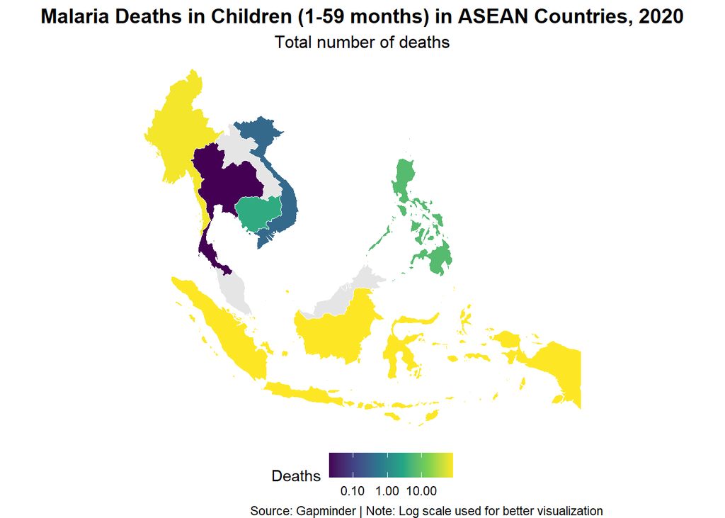

```r
# Prepare malaria data for mapping
malaria_map_data <- combined_data %>%
  select(country, malaria_deaths_2020) %>%
  filter(!is.na(malaria_deaths_2020)) %>%
  mutate(country_std = case_when(
    str_detect(country, "Brunei") ~ "Brunei",
    country == "Cambodia" ~ "Cambodia",
    country == "Indonesia" ~ "Indonesia",
    str_detect(country, "Lao") ~ "Laos",
    country == "Malaysia" ~ "Malaysia",
    country == "Myanmar" ~ "Myanmar",
    country == "Philippines" ~ "Philippines",
    country == "Singapore" ~ "Singapore",
    country == "Thailand" ~ "Thailand",
    str_detect(country, "Vietnam|Viet Nam") ~ "Vietnam",
    TRUE ~ country
  ))

# Join with map data
malaria_map <- asean_region %>%
  left_join(malaria_map_data, by = "country_std")

# Create malaria deaths map
ggplot(malaria_map) +
  geom_sf(aes(fill = malaria_deaths_2020), color = "white", size = 0.3) +
  scale_fill_viridis_c(name = "Deaths",
                       trans = "log10",
                       labels = scales::comma,
                       na.value = "grey90") +
  labs(title = "Malaria Deaths in Children (1-59 months) in ASEAN Countries, 2020",
       subtitle = "Total number of deaths",
       caption = "Source: Gapminder | Note: Log scale used for better visualization") +
  theme_void() +
  theme(plot.title = element_text(hjust = 0.5, size = 14, face = "bold"),
        plot.subtitle = element_text(hjust = 0.5, size = 12),
        legend.position = "bottom")
```

## ASEAN Map: Malnutrition in Children (Most Recent Data)

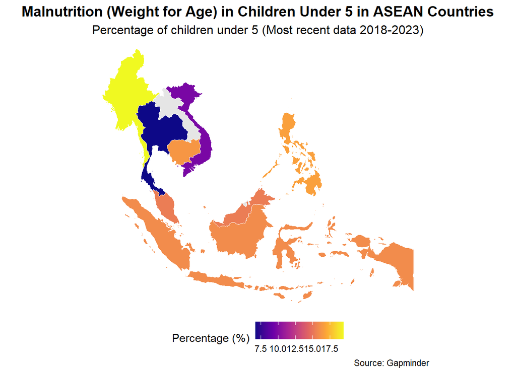

```r
# Prepare malnutrition data for mapping
malnutrition_map_data <- combined_data %>%
  select(country, malnutrition_pct_recent, malnutrition_year) %>%
  filter(!is.na(malnutrition_pct_recent)) %>%
  mutate(country_std = case_when(
    str_detect(country, "Brunei") ~ "Brunei",
    country == "Cambodia" ~ "Cambodia",
    country == "Indonesia" ~ "Indonesia",
    str_detect(country, "Lao") ~ "Laos",
    country == "Malaysia" ~ "Malaysia",
    country == "Myanmar" ~ "Myanmar",
    country == "Philippines" ~ "Philippines",
    country == "Singapore" ~ "Singapore",
    country == "Thailand" ~ "Thailand",
    str_detect(country, "Vietnam|Viet Nam") ~ "Vietnam",
    TRUE ~ country
  ))

# Join with map data
malnutrition_map <- asean_region %>%
  left_join(malnutrition_map_data, by = "country_std")

# Create malnutrition map
ggplot(malnutrition_map) +
  geom_sf(aes(fill = malnutrition_pct_recent), color = "white", size = 0.3) +
  scale_fill_viridis_c(name = "Percentage (%)",
                       option = "plasma",
                       na.value = "grey90") +
  labs(title = "Malnutrition (Weight for Age) in Children Under 5 in ASEAN Countries",
       subtitle = "Percentage of children under 5 (Most recent data 2018-2023)",
       caption = "Source: Gapminder") +
  theme_void() +
  theme(plot.title = element_text(hjust = 0.5, size = 14, face = "bold"),
        plot.subtitle = element_text(hjust = 0.5, size = 12),
        legend.position = "bottom")
```

## Relationship Between Malaria Deaths and Malnutrition

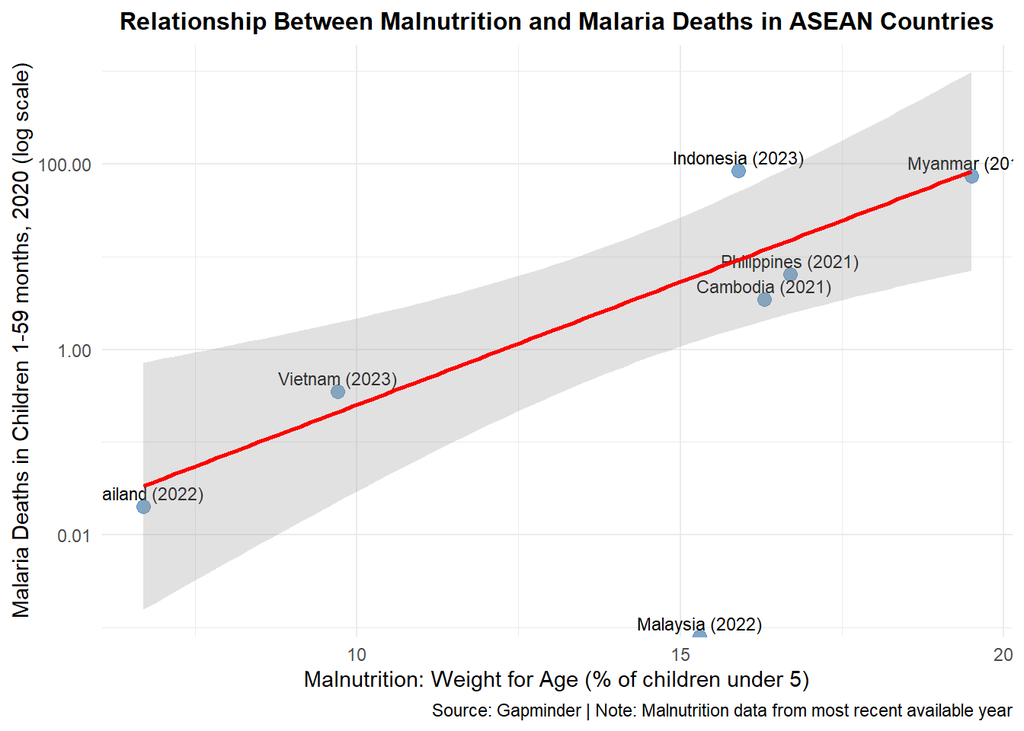

```r
# Create scatterplot showing relationship
scatter_data <- combined_data %>%
  filter(!is.na(malaria_deaths_2020) & !is.na(malnutrition_pct_recent))

ggplot(scatter_data, aes(x = malnutrition_pct_recent, y = malaria_deaths_2020)) +
  geom_point(size = 3, alpha = 0.7, color = "steelblue") +
  geom_text(aes(label = paste0(country, " (", malnutrition_year, ")")),
            vjust = -0.5, hjust = 0.5, size = 3) +
  geom_smooth(method = "lm", se = TRUE, color = "red", alpha = 0.3) +
  scale_y_log10(labels = scales::comma) +
  labs(title = "Relationship Between Malnutrition and Malaria Deaths in ASEAN Countries",
       x = "Malnutrition: Weight for Age (% of children under 5)",
       y = "Malaria Deaths in Children 1-59 months, 2020 (log scale)",
       caption = "Source: Gapminder | Note: Malnutrition data from most recent available year") +
  theme_minimal() +
  theme(plot.title = element_text(hjust = 0.5, size = 12, face = "bold"))
```

```r
# Calculate correlation
if(nrow(scatter_data) >= 2) {
  correlation <- cor(scatter_data$malnutrition_pct_recent,
                     log10(scatter_data$malaria_deaths_2020 + 0.01), # Add small constant for log
                     use = "complete.obs")

  cat("Correlation between malnutrition and log(malaria deaths):", round(correlation, 3))
}
```

```
## Correlation between malnutrition and log(malaria deaths): 0.66
```

```r
# Summary statistics
cat("\nSummary Statistics:\n")
```

```
##
## Summary Statistics:
```

```r
cat("Countries with both indicators available:", nrow(scatter_data), "\n")
```

```
## Countries with both indicators available: 7
```

```r
if(nrow(scatter_data) > 0) {
  cat("Malnutrition range:", round(min(scatter_data$malnutrition_pct_recent), 1),
      "% to", round(max(scatter_data$malnutrition_pct_recent), 1), "%\n")
  cat("Malaria deaths range:", round(min(scatter_data$malaria_deaths_2020), 1),
      "to", round(max(scatter_data$malaria_deaths_2020), 1), "deaths\n")

  cat("\nData years for malnutrition by country:\n")
  for(i in 1:nrow(scatter_data)) {
    cat(scatter_data$country[i], ":", scatter_data$malnutrition_year[i], "\n")
  }
}
```

```
## Malnutrition range: 6.7 % to 19.5 %
## Malaria deaths range: 0 to 84.5 deaths
##
## Data years for malnutrition by country:
## Indonesia : 2023
## Cambodia : 2021
## Myanmar : 2018
## Malaysia : 2022
## Philippines : 2021
## Thailand : 2022
## Vietnam : 2023
```

## Summary Table

```r
# Create a summary table
summary_table <- combined_data %>%
  arrange(desc(malaria_deaths_2020)) %>%
  mutate(
    malaria_deaths_2020 = round(malaria_deaths_2020, 1),
    malnutrition_pct_recent = round(malnutrition_pct_recent, 1)
  ) %>%
  select(country, malaria_deaths_2020, malnutrition_pct_recent, malnutrition_year)

kable(summary_table,
      col.names = c("Country", "Malaria Deaths (2020)", "Malnutrition (%)", "Malnutrition Year"),
      caption = "Malaria Deaths (2020) and Most Recent Malnutrition Data in ASEAN Countries")
```

Malaria Deaths (2020) and Most Recent Malnutrition Data in ASEAN Countries

| Country | Malaria Deaths (2020) | Malnutrition (%) | Malnutrition Year |
| --- | --- | --- | --- |
| Indonesia | 84.5 | 15.9 | 2023 |
| Myanmar | 74.0 | 19.5 | 2018 |
| Philippines | 6.4 | 16.7 | 2021 |
| Cambodia | 3.4 | 16.3 | 2021 |
| Vietnam | 0.3 | 9.7 | 2023 |
| Thailand | 0.0 | 6.7 | 2022 |
| Brunei | 0.0 | NA | NA |
| Malaysia | 0.0 | 15.3 | 2022 |
| Singapore | 0.0 | NA | NA |

## Interpretation

Based on the analysis of malaria deaths (2020) and malnutrition (most recent data 2018-2023) in ASEAN countries:

**Key Findings:**

1. **Data Availability**: The analysis successfully obtained data for 7 out of 10 ASEAN countries for both indicators. Complete data is available for Indonesia, Cambodia, Myanmar, Malaysia, Philippines, Thailand, and Vietnam. Brunei and Singapore lack malnutrition data.
2. **Malaria Burden**: Indonesia shows the highest malaria deaths (84.5 deaths) followed by Myanmar (74.0 deaths). Several countries (Brunei, Malaysia, Singapore, Thailand) have very low or zero malaria deaths, indicating successful malaria control programs.
3. **Malnutrition Patterns**: Myanmar shows the highest malnutrition rate (19.5% in 2018), while Thailand has the lowest (6.7% in 2022). Most countries show malnutrition rates between 15-17%.
4. **Relationship**: There is a **moderate positive correlation (r = 0.66)** between malnutrition rates and malaria deaths in ASEAN countries, suggesting that countries with higher malnutrition rates tend to have higher malaria mortality.

**Limitations:**

- **Temporal Mismatch**: Malnutrition data spans different years (2018-2023) while malaria data is from 2020, which may affect the correlation analysis.
- **Sample Size**: Only 7 countries had complete data, limiting statistical power for correlation analysis.
- **Causality**: The cross-sectional design cannot establish whether malnutrition causes higher malaria mortality or if both reflect underlying socioeconomic factors.
- **Confounding Variables**: Healthcare infrastructure, economic development, climate, and vector control programs are not considered in this analysis.

**Recommendations:**

1. **Integrated Programs**: Countries with high burdens of both indicators should consider integrated nutrition and malaria control programs.
2. **Data Collection**: Improve data collection for malnutrition indicators across all ASEAN countries.
3. **Research**: Longitudinal studies are needed to better understand the causal relationship between malnutrition and malaria outcomes.
4. **Regional Surveillance**: Establish coordinated monitoring systems for both indicators across ASEAN.

This analysis provides evidence for the interconnected nature of malnutrition and malaria mortality in the ASEAN region and supports the need for comprehensive public health approaches that address both nutritional deficiencies and infectious disease prevention.

## My reflection

Using Cursor for automatic data analysis and reporting feels like unlocking a new level of efficiency and clarity. Its ability to streamline complex datasets into digestible insights allows me to focus more on interpretation and strategy rather than manual processing. The seamless integration of code and context makes the workflow intuitive, and the collaborative environment encourages iterative thinking. Overall, it’s like having a smart co-pilot that not only accelerates the journey but also sharpens the destination.